# Project #1

Dmitrii Podgalo

24/10/2021

## Load Data

```r
read_data <- function(path = "../data/", pattern = '*.csv', ...) {
  do.call(rbind, lapply(list.files(path, pattern), function(file) read.csv(paste0(path, file))))
}
td <- read_data()
```

## EDA

Transform vars to factor:

```r
td$Sex <- factor(td$Sex)
td$Sport <- factor(td$Sport)
```

Check our data:

```r
str(td)
head(td)
summary(td)
```

Remove duplicates:

```r
td <- unique(td)
```

Remove extremely data: 1. The oldest athlete was 72. 2. The tallest athlete was 218 cm. 3. The easiest athlete can’t be 7 kg.

```r
td <- td[td$Age <= 72,]
td <- td[-which.max(td$Height),]
td <- td[-which.min(td$Weight),]
```

Remove rows that fully have NA:

```r
td <- td[!(grepl('NA', rownames(td))),]
```

## Tasks

### # 3

```r
td %>%
  filter(Year == 1992) %>%
  group_by(Sex) %>%
  summarise(min(Age))
```

```
## # A tibble: 2 × 2
##   Sex   `min(Age)`
##   <fct>      <int>
## 1 F             12
## 2 M             11
```

### # 4

```r
td %>%
  group_by(Sex) %>%
  select(Height) %>%
  summarise(across(.f = list(mean = mean, sd = sd), na.rm = T))
```

```
## # A tibble: 3 × 3
##   Sex   Height_mean Height_sd
##   <fct>       <dbl>     <dbl>
## 1 F            168.      8.77
## 2 G            182      NA
## 3 M            179.      9.36
```

### # 5

```r
td %>%
  filter(Sex == 'F', Sport == 'Tennis', Year == 2000) %>%
  select(Height) %>%
  summarise(across(.f = list(mean = mean, sd = sd), na.rm = T)) %>%
  mutate(across(everything(), round, 1))
```

```
##   Height_mean Height_sd
## 1         172       6.5
```

### # 6

```r
td %>%
  filter(Year == 2006) %>%
  arrange(desc(Weight)) %>%
  slice(1) %>%
  select(Sport)
```

```
##         Sport
## 8103 Skeleton
```

### # 7

```r
td %>%
  filter(Year == 1980:2010, Sex == 'F', Medal == 'Gold') %>%
  summarise(Golds = n())
```

```
##   Golds
## 1    76
```

### # 8

```r
td %>%
  filter(Name == 'John Aalberg') %>%
  summarise(Count = n())
```

```
##   Count
## 1     8
```

### # 9

```r
sort(table(cut(td$Age, seq(15, 55, by=10), right=F, include.lowest=T)), d=T)
```

```
##
## [15,25) [25,35) [35,45) [45,55]
##  130008  110812   14806    3011
```

### # 10

```r
length(unique(td[td$Year == 2002,]$Sport)) - length(unique(td[td$Year == 1994,]$Sport))
```

```
## [1] 3
```

### # 11

```r
td %>%
  filter(Medal == c('Gold', 'Silver', 'Bronze')) %>%
  group_by(Medal, Season, Team) %>%
  summarise(Count = n()) %>%
  arrange(-Count) %>%
  slice_max(3)
```

```
## # A tibble: 6 × 4
## # Groups:   Medal, Season [6]
##   Medal  Season Team          Count
##   <chr>  <chr>  <chr>         <int>
## 1 Bronze Summer United States   353
## 2 Bronze Winter Finland          68
## 3 Gold   Summer United States   770
## 4 Gold   Winter Canada           93
## 5 Silver Summer United States   403
## 6 Silver Winter United States   103
```

### # 12

```r
z_normalize <- function(x) {
  (x - mean(x, na.rm = TRUE)) / sd(x, na.rm = TRUE)
}

td %>%
  mutate(Height_z_scores = z_normalize(Height))
```

### # 13

```r
min_max_normalize <- function(x) {
  (x - min(x, na.rm = TRUE)) / (max(x, na.rm = TRUE) - min(x, na.rm = TRUE))
}

td %>%
  mutate(Height_min_max_scaled = min_max_normalize(Height))
```

### # 14

```r
stat_tables <- function(varr) {
v <- td %>%
  distinct_at(vars(Name), .keep_all = T) %>%
  filter(Sex == c('M', 'F')) %>%
  t.test(.[,varr] ~ .[, 'Sex'], data = ., na.action = na.omit)

data.frame(t.value = v$statistic, df = v$parameter, p.value = v$p.value, 'F mean' = v$estimate[1], 'M mean' = v$estimate[2], row.names = c()) %>%
  kbl(caption = paste(varr, 'comparison')) %>%
  kable_classic(full_width = F, html_font = "Cambria")
}
```

Height comparison

| t.value | df | p.value | F.mean | M.mean |
| --- | --- | --- | --- | --- |
| -123 | 31402 | 0 | 169 | 180 |

Weight comparison

| t.value | df | p.value | F.mean | M.mean |
| --- | --- | --- | --- | --- |
| -136 | 36298 | 0 | 61.4 | 76.6 |

Age comparison

| t.value | df | p.value | F.mean | M.mean |
| --- | --- | --- | --- | --- |
| -44.2 | 32734 | 0 | 22.9 | 25 |

### # 15

Look at **Task 11**. We can see that the first countries are “Western countries” and the most medals belong to USA. Here we can formulate 3 interrelated hypotheses:

1. It can mean that Olympic Games are from the West and the Western countries has an advantage in own sports.
2. It can mean that the economic indicators of the country are also expressed in sports. More economically developed country has more achievements in sports.
3. Below we can see that US has more “NA” medals, it means that sportsmen count can correlate with medals count and US just has more sportsmen.

```r
td %>%
  group_by(Medal, Season, Team) %>%
  summarise(Count = n()) %>%
  arrange(-Count) %>%
  slice_max(3) %>%
  filter(is.na(Medal))
```

```
## # A tibble: 2 × 4
## # Groups:   Medal, Season [2]
##   Medal Season Team          Count
##   <chr> <chr>  <chr>         <int>
## 1 <NA>  Summer United States  9374
## 2 <NA>  Winter United States  2788
```

### # 16

#### First hypothesis

Conditions for the use of the chi-square:

1. Normal distribution of variables.
2. All observations are independent.

H0: Young sportsmen (up to and including 25 years) hasn’t an advantage over the old ones. H1: Young sportsmen (up to and including 25 years) has an advantage over the old ones.

```r
young_gold <- td %>%
  filter(Age <= 25, Medal == 'Gold') %>%
  summarise(n())

young_all <- td %>%
  filter(Age <= 25) %>%
  summarise(n())

old_gold <- td %>%
  filter(Age > 25, Medal == 'Gold') %>%
  summarise(n())

old_all <- td %>%
  filter(Age > 25) %>%
  summarise(n())

young <- young_gold[1,] / young_all[1,]
old <- old_gold[1,] / old_all[1,]

sum_table = data.frame(young = young, old = old)

chisq.test(sum_table)
```

```
##
##  Chi-squared test for given probabilities
##
## data:  sum_table
## X-squared = 5e-04, df = 1, p-value = 1
```

We can see that *X-squared is less than 0.004*, *p-value is 0.982* and *df 1*. It means that no significant difference was found and H0 is true.

#### Second hypothesis

H0: Every the summer games US gets more gold medals. H1: Every the summer games US don’t gets more gold medals.

Conditions for the use of the correlation coefficient:

1. Normal distribution of variables.
2. The relationship is linear and monotonic.

```r
lm_table_US <- td %>%
  filter(Team == 'United States', Medal == 'Gold', Season == 'Summer') %>%
  group_by(Year) %>%
  summarise(Count = n())
cor.test(y = lm_table_US$Count, x = lm_table_US$Year)
```

```
##
##  Pearson's product-moment correlation
##
## data:  lm_table_US$Year and lm_table_US$Count
## t = 7, df = 26, p-value = 6e-07
## alternative hypothesis: true correlation is not equal to 0
## 95 percent confidence interval:
##  0.588 0.897
## sample estimates:
##   cor
## 0.788
```

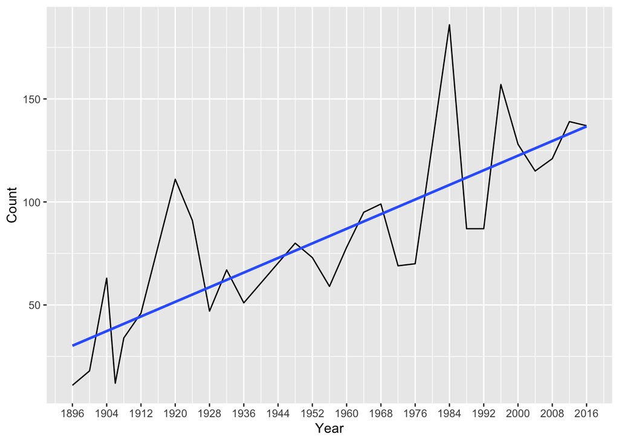